# Poisson linear models

Peter Ralph

Advanced Biological Statistics

# Count data

## A hypothetical situation:

1. We have **counts** of mutations,
2. from some individuals of different **ages** and past **exposures** to solar irradiation,
3. of two **genotypes**.

*Model:*

- Counts are **Poisson**,
- with mean that depends on age and exposure,
- but effect of exposure depends on genotype.
1. Counts are **Poisson**,
2. with mean that depends on age and exposure,
3. but effect of exposure depends on genotype.

$$\begin{aligned}
Z_i &\sim \Poisson(\mu_i) \\
\end{aligned}$$

1. Counts are **Poisson**,
2. with mean that depends on age and exposure,
3. but effect of exposure depends on genotype.

$$\begin{aligned}
Z_i &\sim \Poisson(\mu_i) \\
\mu_i &= a + b \times \text{age}_i + c \times \text{exposure}_i
\end{aligned}$$

1. Counts are **Poisson**,
2. with mean that depends on age and exposure,
3. but effect of exposure depends on genotype.

$$\begin{aligned}
Z_i &\sim \Poisson(\mu_i) \\
\mu_i &= a_{g_i} + b \times \text{age}_i + c_{g_i} \times
\text{exposure}_i
\end{aligned}$$

1. Counts are **Poisson**,
2. with mean that depends on age and exposure,
3. but effect of exposure depends on genotype.

$$\begin{aligned}
Z_i &\sim \Poisson(\mu_i) \\
\mu_i &= \exp\left( a_{g_i} + b \times \text{age}_i \right. \\
&\qquad \left. {} + c_{g_i} \times \text{exposure}_i \right)
\end{aligned}$$

# Poisson modeling, in practice

## The data

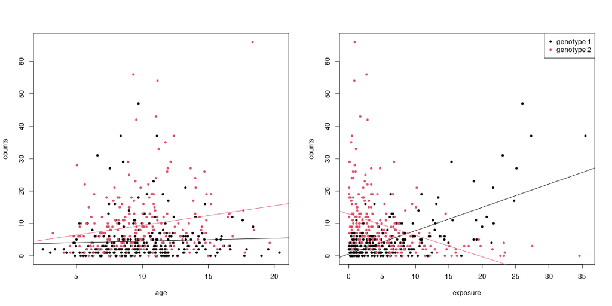

Here are the data:

```r
head( countdata <- read.table("data/poisson_counts.tsv", header=TRUE, stringsAsFactors=TRUE) )
```

```
##   genotype       age   exposure counts
## 1        A 11.961887 24.7839999     17
## 2        B  8.699680  2.4985780     12
## 3        B 13.044583  0.6582441      5
## 4        A 16.193124  2.5269076      3
## 5        B  5.438608 23.3953875      1
## 6        A 14.261364  8.2820704      2
```

## A GLM

```r
bf <- brmsformula(counts ~ 0 + genotype + age + genotype:exposure)
get_prior(bf, data=countdata)
```

```
##                 prior class               coef group resp dpar nlpar bound       source
##                (flat)     b                                                     default
##                (flat)     b                age                             (vectorized)
##                (flat)     b          genotypeA                             (vectorized)
##                (flat)     b genotypeA:exposure                             (vectorized)
##                (flat)     b          genotypeB                             (vectorized)
##                (flat)     b genotypeB:exposure                             (vectorized)
##  student_t(3, 0, 4.4) sigma                                                     default
```

```r
fit1 <- brm(
   counts ~ 0 + genotype + age + genotype:exposure,
   family=poisson(link='log'),
   prior=set_prior("normal(0, 1)", class="b"),
   data=countdata
)
print(fit1)
```

```
##  Family: poisson
##   Links: mu = log
## Formula: counts ~ 0 + genotype + age + genotype:exposure
##    Data: countdata (Number of observations: 500)
##   Draws: 4 chains, each with iter = 2000; warmup = 1000; thin = 1;
##          total post-warmup draws = 4000
##
## Population-Level Effects:
##                    Estimate Est.Error l-95% CI u-95% CI Rhat Bulk_ESS Tail_ESS
## genotypeA              0.30      0.07     0.16     0.44 1.00     1301     1626
## genotypeB              2.21      0.06     2.09     2.34 1.00     1358     1765
## age                    0.05      0.01     0.04     0.06 1.00     1334     1829
## genotypeA:exposure     0.09      0.00     0.09     0.10 1.00     2802     2534
## genotypeB:exposure    -0.12      0.01    -0.13    -0.10 1.00     2685     2507
##
## Draws were sampled using sampling(NUTS). For each parameter, Bulk_ESS
## and Tail_ESS are effective sample size measures, and Rhat is the potential
## scale reduction factor on split chains (at convergence, Rhat = 1).
```

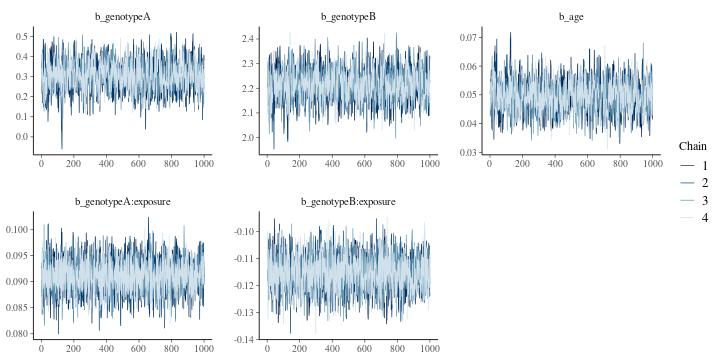

```r
mcmc_trace(fit1, regex_pars=c("b_.*"))
```

Posterior distributions of the parameters:

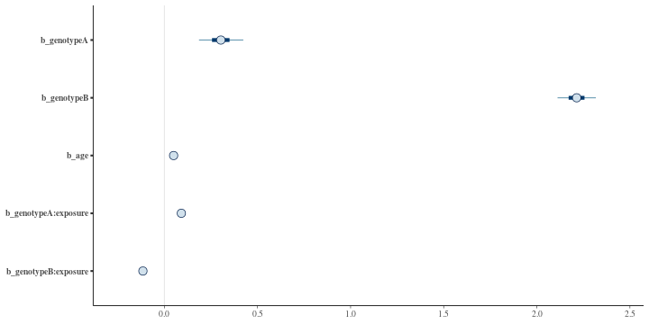

# Goodness of fit

## Posterior predictive simulations

*Idea:* Let’s simulate up data *under this model* and see if it looks like the real data.

A bunch of times, we’ll

1. pick a set of parameters from the posterior
2. compute the vector of means (`mu`)
3. simulate a vector of Poisson counts with mean `mu`

… with the `pp_check` function!

## The data are *overdispersed* relative to our simulations

```r
pp_check(fit1, type='intervals', x="order")
```

```
## Using all posterior draws for ppc type 'intervals' by default.
```

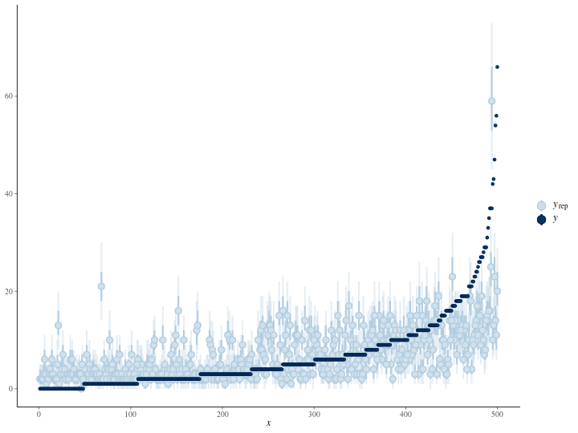

## One solution:

Use the `negbinomial` family

… which introduces more randomness:

$$\begin{aligned}
Z_i &\sim \Poisson(M_i) \\
M_i &\sim \Gam(\text{mean}=\mu_i, \text{shape}=r) \\
\mu_i &= \exp(y_i) \\
y_i &= a_{g_i} + b \times \text{age}_i \\
&\qquad {} + c_{g_i} \times \text{exposure}_i
\end{aligned}$$

```r
fit2 <- brm(
   counts ~ 0 + genotype + age + genotype:exposure,
   family=negbinomial(link='log'),
   prior=set_prior("normal(0, 1)", class="b"),
   data=countdata
)
print(fit2)
```

```
##  Family: negbinomial
##   Links: mu = log; shape = identity
## Formula: counts ~ 0 + genotype + age + genotype:exposure
##    Data: countdata (Number of observations: 500)
##   Draws: 4 chains, each with iter = 2000; warmup = 1000; thin = 1;
##          total post-warmup draws = 4000
##
## Population-Level Effects:
##                    Estimate Est.Error l-95% CI u-95% CI Rhat Bulk_ESS Tail_ESS
## genotypeA              0.17      0.15    -0.14     0.47 1.00     1719     1659
## genotypeB              2.05      0.15     1.76     2.33 1.00     1847     1603
## age                    0.06      0.01     0.04     0.09 1.00     1753     1756
## genotypeA:exposure     0.09      0.01     0.08     0.11 1.00     3105     2326
## genotypeB:exposure    -0.10      0.01    -0.13    -0.08 1.00     3703     2711
##
## Family Specific Parameters:
##       Estimate Est.Error l-95% CI u-95% CI Rhat Bulk_ESS Tail_ESS
## shape     1.95      0.17     1.63     2.31 1.00     3243     2506
##
## Draws were sampled using sampling(NUTS). For each parameter, Bulk_ESS
## and Tail_ESS are effective sample size measures, and Rhat is the potential
## scale reduction factor on split chains (at convergence, Rhat = 1).
```

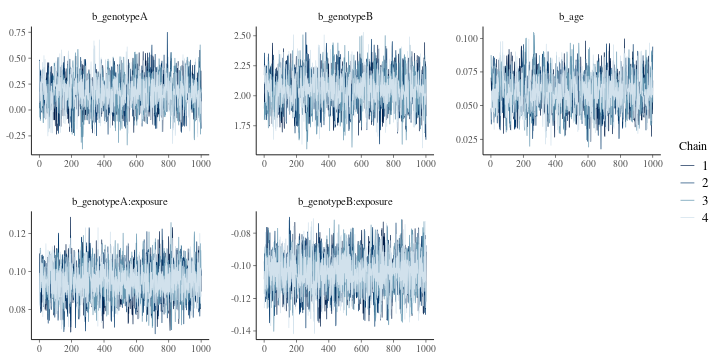

```r
mcmc_trace(fit2, regex_pars=c("b_.*"))
```

Posterior distributions of the parameters:

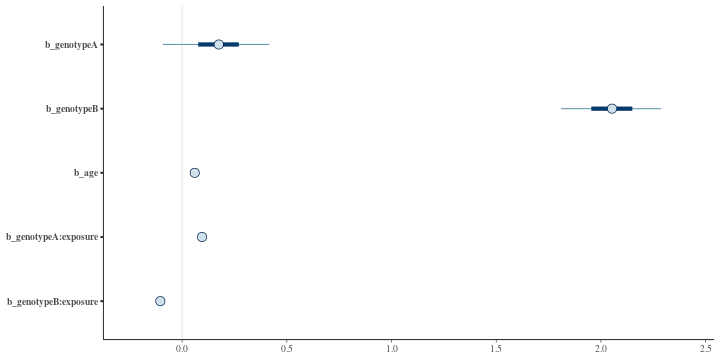

```r
pp_check(fit2, type='intervals', x="order")
```

```
## Using all posterior draws for ppc type 'intervals' by default.
```

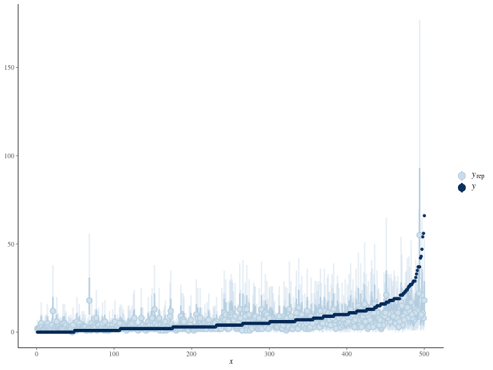